# Aquaculture Model

2019-02-11

### Objective: Step through optimal rotations for a generic totoaba farm.

#### Introduction

Our objective requires functions and inputs for the growth, mortality, trimming, and harvest of totoaba over *n* cages.

We first build out intermediate functions to find both constant and variable parameter values.

These are:

1. Lengths at Age
2. Mortalities at Age
3. Weights at Length
4. Numbers at Age
5. Maw Yields at Length
6. Maw Prices at Weight
7. Maw Revenues at Weight and Price
8. Meat Revenues at Weight
9. Feed Requirements at Weight | No-Harvest Cost
10. Feed Requirement at Stocking | Harvest Cost

We next compile bioeconomic inputs, intermediate results, and additional parameters for an iterative Faustmann model.

We program and run the Faustmann model for a single cage, then for multiple cages, and finally for a sensitivity analysis.

Lastly, we create figures for intermediate calculations and results of the Faustmann model.

#### Lengths at Age

We estimate lengths at age from a Von Bertalanffy function.

Our parameter estimates follow from INAPESCA (2018) and EOF (2018). **This section needs the whole estimation process from Excel.**

$L(t) = L_\infty ( 1 - e^{ - K ( t - t_0 )})$

[output not shown]

```r
# Von Bertalanffy function.
fn_vb = function(linf, k, t, t_0){l = linf * ( 1 - exp( - k * ( t - t_0)))}

# Set parameter values for future reference.
vb_linf = 200
vb_k    = 0.155 #0.22856
vb_t0   = -0.65
```

#### Mortalities at Age

We estimate mortalities at age from a report by month over two years from Cygnus Ocean Farms, SA de CV.

Supposing a mortality trend $m = \beta_1 * e^{\beta_2a}$, we use R function stats::nls to estimate parameters.

```r
a_months = seq(1, 24)
m_months = c(rep(5.00, 2),
             rep(2.40, 2),
             rep(1.60, 2),
             rep(1.15, 2),
             rep(1.00, 3),
             rep(0.80, 3),
             0.50,
             rep(0.40, 6),
             0.30,
             rep(0.20, 2))

dat_m = tibble(a_months, m_months)

# Specification for nonlinear regression:
am_reg = nls(m_months ~ b1 * exp(b2 * a_months), dat_m, start = list(b1 = 8.00, b2 = - 1.00))

# Clean up output:
am_reg_tidy = tidy(am_reg, conf.int = TRUE, conf.level = 0.95)
dat_m_est = augment(am_reg)
```

Results plug into a function:

$M = \beta_1 * e^{\beta_2a}$

| Variable | Definition | Value |
| --- | --- | --- |
| *m* | Cohort Mortality (%) |  |
| *a* | Age (Months) |  |
| $\beta_1$ | Parameter | 5.9365347 |
| $\beta_2$ | Parameter | -0.1987843 |

We annualize mortalities at age to match other data.

To keep a realistic non-zero mortality-at-age estimate, we add an annualized proportional mortality of 0.01.

The indefinite integral of mortality-at-age, i.e. cumulative mortality, is also defined as: $M = \frac{\beta_1 * e^{\beta_2a}}{\beta_2}$

```r
# Set marginal mortality.
fn_am_marg = function(a, b1, b2){m = b1 * exp(b2 * a * 12) + 1} # "+ 1" adds lower threshold of 0.01 on mortality.
                                                                # "* 12" converts from months to years.

# Set parameters for reference.
am_b1 = am_reg_tidy$estimate[1]
am_b2 = am_reg_tidy$estimate[2]
```

#### Weights at Length

We estimate weights at age from a functional form and parameters values from INAPESCA (2018). **Hey Miguel, is this right?**

$W = aL^b$

| Variable | Definition | Value |
| --- | --- | --- |
| *W* | Weight (Kilograms) |  |
| *L* | Length (Centimeters) |  |
| *a* | Parameter | 0.000004128 |
| *b* | Parameter | 3.246740000 |

```r
# Generic length-to-weight conversion.
fn_lw = function(a, l, b){w = a * l ^ b
                          return(w)}

# Set parameter values for future reference.
wl_a = 0.000004128
wl_b = 3.24674
```

#### Numbers at Age

$T = n_t^* - n_{t-1}^* * m_{t-1}$

```r
# Density is highest possible kilograms per cubic meter without density-dependence slowing growth.
density = 160000 # Goto or Miguel - is this from Felipe?

# Size is first saleable size in kilograms.
size = 2 # Communications with EOF (2018).

a = seq(1, 25)
w = fn_lw(wl_a, fn_vb(vb_linf, vb_k, a, vb_t0), wl_b)
fn_ns = function(density, w){ns = density / w} # Note lag on age to get last year's mortality.

# Cohort count at first saleable size is the ratio of density in kgm^-3 to size in kg.
nsale = density / size

# Initial cohort count is density at first saleable size, plus cumulative mortality at first saleable age.
# Casually, nstart = nsale + mort(a(l(wsale))).
# Cumulative mortality to first saleable age:
a_sale = (vb_t0 - 1 / vb_k * (log(1 - ((size / wl_a) ^ (1 / wl_b))/vb_linf))) # Inverse Von Bertalanffy.

# Initial stock to reach optimal density at first salable size:
nstart = nsale * (100 / (100 - fn_am_marg(a_sale, am_b1, am_b2))) *
  (100 / (100 - fn_am_marg(1, am_b1, am_b2))) *
  (100 / (100 - fn_am_marg(1, am_b1, am_b2)))
```

#### Maw Weights at Individual Weight

For a stock of $n_{a, t}$ totoaba cultivated for *a* years in year *t* to weight $w_{a, t}$ for a total round weight of $x_{a, t}$, maw yield $y_{a, t}$ depends on wet maw yield ratio $c^{maw}_{a, t}$ and dry yield ratio $k$.

$y^{maw}_{a, t} = w_{a, t}n_{a, t}c^{maw}_{a, t}k^{maw}_{dry}$

| Variable | Definition | Value |
| --- | --- | --- |
| $y^{maw}$ | Cohort Dry Maw Yield (Kilograms) |  |
| *w* | Individual Round Weight (Kilograms) |  |
| *n* | Cohort Count |  |
| $c^{maw}$ | Yield of maw from round weight. | 0.0161 |
| $k^{maw}$ | Yield of dry maw from wet maw. | 0.3100 |

```r
fn_wm = function(w, n, c, k){ymaw = w * n * c * k}

# Parameters from cultivated sample (UABC & PhD) and from inapesca wild sample:
wm_c = 0.0161
wm_k = 0.31
```

#### Maw Prices at Maw Weight and Market Supply

We estimate price from multiple regression of price per gram of maw on tonnes of dry maw supplied and grams per maw.

```r
#fn_mp = function(w, b0, bw, bq, q, bc, c){pmaw = b0 + w ^ bw + bq * q + bc * c}
fn_mp = function(w, b0, b1, b2, q){pmaw = (q * b1 + (w * 1000) ^ b2 + b0) * 1000} # Factors of 1000 convert from grams to kilograms.

# Parameters from regression.
mp_b0 = 82.99177
mp_b1 = -5.28312
mp_b2 = 0.52540
mp_q = 10 # Note that 14 fills in for a reasonable quantity at market from poaching. In the Faustmann implementation, mp_q is lag quantity supplied.
```

#### Maw Revenues at Maw Price and Yield

For a dry maw yield $y^{maw}$ in kilograms, revenue depends on price.

```r
fn_mr = function(ymaw, pmaw){rmaw = ymaw * pmaw}
```

#### Wet Weight Revenues at Yield

For a stock of *n* totoaba cultivated for *a* years in year *t* for an individual round weight of $w_{a, t}$, revenue depends on price.

$R^{round}_{a, t} = w_{a, t} * n_{a, t} * p^{round}$

```r
fn_fr = function(w, n, pround){rround = w * n * pround}

# Parameter from market research:
pround = 6.50 # Price from Sistema Nacional de Informacion e Integracion de Mercados (2019)
```

#### Feed Requirements at Weight

We assume a constant daily feed requirement proprotional to organism mass.

Calculations for an alternative estimation of feed requirement follow.

For reasons, we assume functional form $F = \beta_1 * w^{\beta_2}$

Those results plug into a feed-at-weight function:

[output not shown]

```r
# Set cumulative feed requirement.
fn_f_cumu = function(w, b1, b2){F = b1 * w ^ b2}

# Set marginal feed requirement.
fn_f_marg = function(w, b1, b2){f = b1 * b2 * w}

# Set parameters for reference.
f_b1 = 0.01
f_b2 = 1.00
```

#### No-Harvest Cost

We estimate the cost of maintaining a cohort in a cage from cohort size, cohort weight, marginal feed requirement, feed cost, and generalized overhead costs.

$c_{h = 0} = n_a * c_f * f(w) + o$

```r
# Marginal cohort cost.
fn_ch0 = function(w, b1, b2, cf, n, o){ch0 = n * cf * fn_f_marg(w, b1, b2) * 365 + o} # FCR is daily, so multiply by days.

# Parameters.
#  Cost, USD/kg.
ch0_cf = 2 # Intrafish (2019), pers. comm. Garrett Goto, Earth Ocean Farms S.A. de C.V. (2019).

# Overhead, from eight cages for ten years down to one cage for one year.
o = 170000 # Goto, source!
```

#### Harvest Cost

We estimate the cost of harvesting with instantaneous restocking from optimal stocking density at first age for optimal stocking density at first salable age, cost of fry for restocking, and generalized overhead costs.

```r
ch1 = nstart * 2 + o # Fry Cost (CREMES).
```

#### Intermediate Results Summary

With intermediate results ready for the Faustmann implementation, we run a few graphs out for later reference.

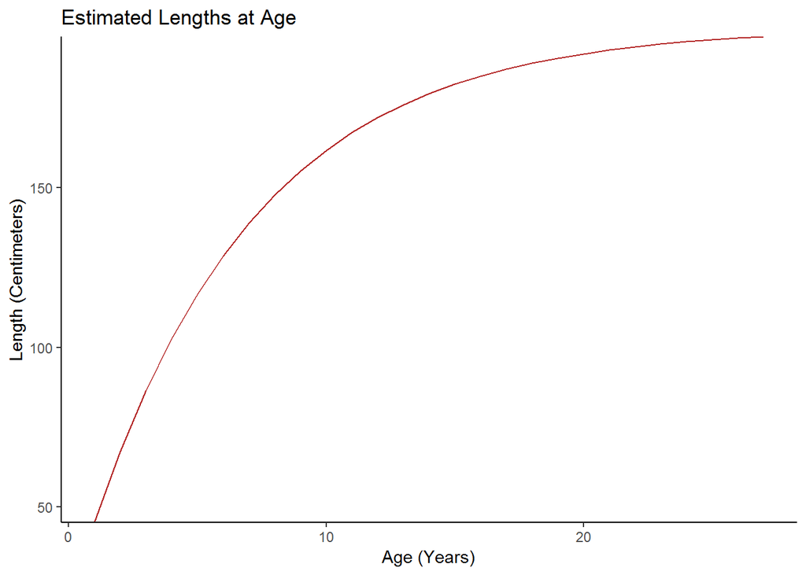

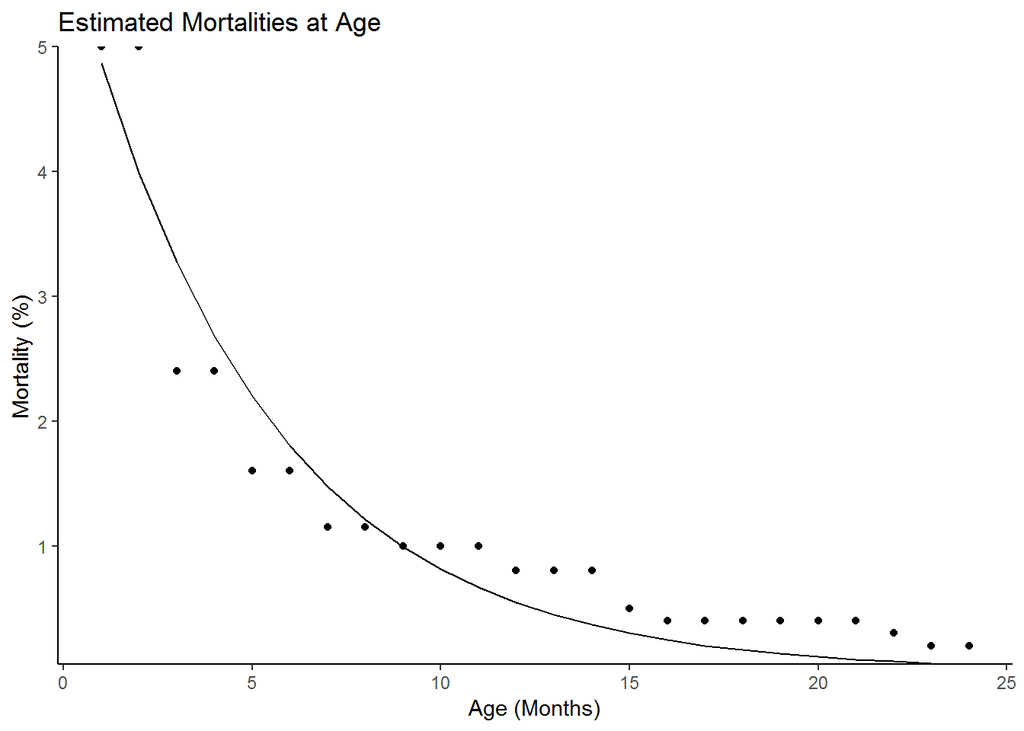

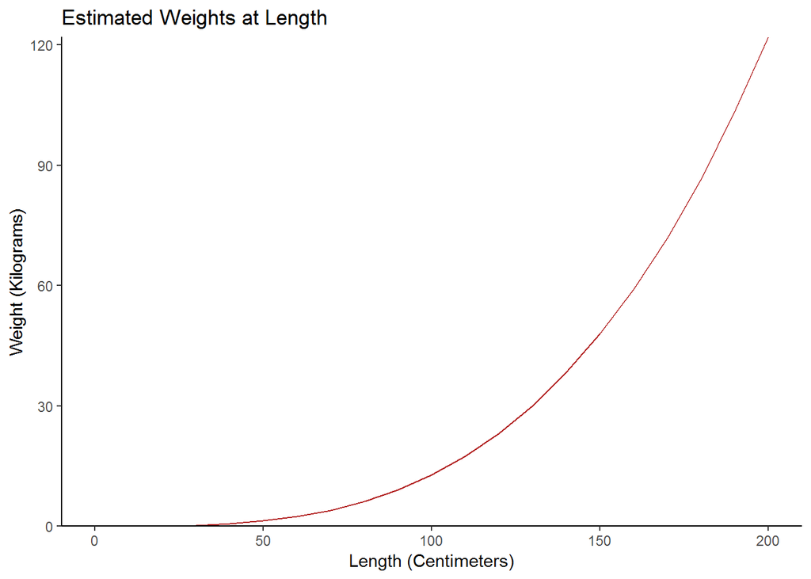

#### Run 11 + Profit